# Tidyverse Solution

Author

Rachel Stagner

Published

October 4, 2026

```r
if(!require("pacman")) install.packages("pacman")
pacman::p_load(tidyverse, gapminder, broom)
```

## Problem 1

We were asked to create a dataframe, `df`, using the following code:

```r
tribble( ~x,    ~y,    ~w,    ~z,
              210,   300,   220,   180,
              102,   100,   119,   187,
              176,   175,   188,   173,
              87,    95,   91,     94,
              202,   210,  234,    218,
              110,   122,  131,    128,
) -> dt
```

### 1a.

Use the `map()` function from the `purrr` package in tidyverse to find the mean of each column of the dataframe `dt`.

```r
dt_mean <- map(dt, mean) #uses the 'map' function to find the mean
dt_mean #prints the mean
```

```
$x
[1] 147.8333

$y
[1] 167

$w
[1] 163.8333

$z
[1] 163.3333
```

### 1b.

Use the `map()` function to find the standard deviation of each column in the dataframe `dt`.

```r
dt_sd <- map (dt, sd) #uses 'map' to find the sd of each column
dt_sd #print the result
```

```
$x
[1] 54.45151

$y
[1] 79.12016

$w
[1] 58.40348

$z
[1] 44.66617
```

### 1c.

Use the `map_df()` function to calculate the square root for each value in the dataframe `dt`. This function returns the results in another dataframe.

```r
dt_sqrt <- map_df(dt, sqrt) #find the square root of each value
dt_sqrt #print the resulting df
```

```
# A tibble: 6 × 4
      x     y     w     z
  <dbl> <dbl> <dbl> <dbl>
1 14.5  17.3  14.8  13.4
2 10.1  10    10.9  13.7
3 13.3  13.2  13.7  13.2
4  9.33  9.75  9.54  9.70
5 14.2  14.5  15.3  14.8
6 10.5  11.0  11.4  11.3
```

### 1d.

Use the `summary()` function to find the min, max, mean, median, 1st and 3rd quartile of the columns of the dataframe. This is a base R function.

```r
summary(dt) #use the summary function in base r to calculate summary stats for dt
```

```
       x               y               w               z
 Min.   : 87.0   Min.   : 95.0   Min.   : 91.0   Min.   : 94.0
 1st Qu.:104.0   1st Qu.:105.5   1st Qu.:122.0   1st Qu.:139.2
 Median :143.0   Median :148.5   Median :159.5   Median :176.5
 Mean   :147.8   Mean   :167.0   Mean   :163.8   Mean   :163.3
 3rd Qu.:195.5   3rd Qu.:201.2   3rd Qu.:212.0   3rd Qu.:185.2
 Max.   :210.0   Max.   :300.0   Max.   :234.0   Max.   :218.0
```

## Problem 2

To see what was happening in this problem, I followed the provided solution to build a function that used a for loop to create a small numeric vector of 10 values according to the instructions.

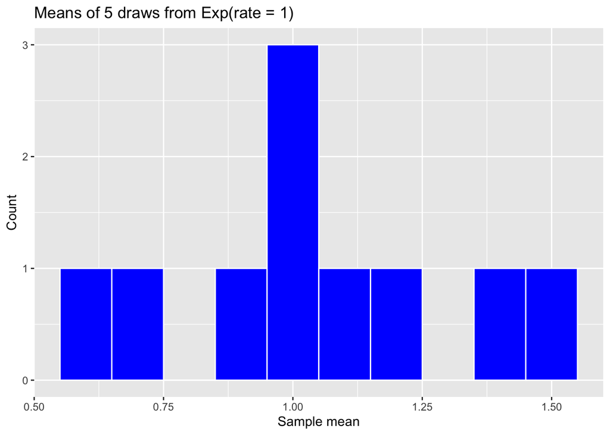

```r
#making the example solution loop function with 10 reps

exp_means_loop <- function(n = 5, reps = 10) {
  means <- vector(mode = "numeric", length = reps) #creates a empty vector

for (i in 1:reps) {                #repeats the number of "reps" (10)
  means[i] <- mean(rexp(n, rate = 1)) #draw n, take the mean, and store it
}

output <- data.frame(sample_mean = means) #creates a df from the means vector

#creates a histogram of the results
ggplot(output, aes(sample_mean)) +
  geom_histogram(binwidth = 0.1, fill = "blue", color = "white") +
  labs(title = paste("Means of", n, "draws from Exp(rate = 1)"),
       x = "Sample mean",
       y = "Count"
       )
}

exp_means_loop() #prints the results
```

### Problem 2a

For 2a, we were asked to replace the for loop with a `map()` function from the `purrr` package in tidyverse. I also increased the number of reps to 10,000 as the original problem asked:

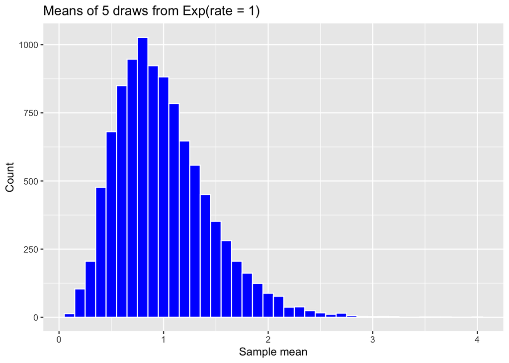

```r
#adding the map function and upping the reps to 10000

exp_means_loop_2a <- function(n = 5, reps = 10000) {

means_2a <- map_dbl(1:reps, function(i) mean(rexp(n, rate = 1))) #map function creates & fills vector

output_2a <- data.frame(sample_mean = means_2a) #creates a df from the means vector

#creates a histogram of the results
ggplot(output_2a, aes(sample_mean)) +
  geom_histogram(binwidth = 0.1, fill = "blue", color = "white") +
  labs(title = paste("Means of", n, "draws from Exp(rate = 1)"),
       x = "Sample mean",
       y = "Count"
  )
}

exp_means_loop_2a()
```

### Problem 2b

Next, we were asked to use the `replicate()` function from Base R.

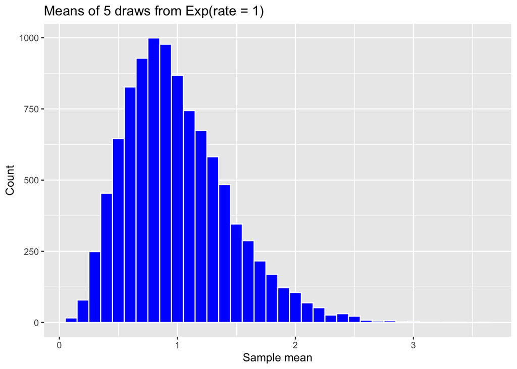

```r
#2b using a replicate function

exp_means_loop_2b <- function(n = 5, reps = 10000) {

  means_2b <- replicate(reps, mean(rexp(n, rate = 1))) #replicate function creates & fills vector

  output_2b <- data.frame(sample_mean = means_2b) #creates a df from the means vector

  #creates a histogram of the results
  ggplot(output_2b, aes(sample_mean)) +
    geom_histogram(binwidth = 0.1, fill = "blue", color = "white") +
    labs(title = paste("Means of", n, "draws from Exp(rate = 1)"),
         x = "Sample mean",
         y = "Count"
    )
}
exp_means_loop_2b()
```

### Problem 2c

Finally, we were asked to use another for loop that would print out histograms for sample sizes of 5, 10, and 20. To do this, I wrapped the function in another for loop. I chose to use the function from problem 2a, aka the `map()` function, to complete this step.

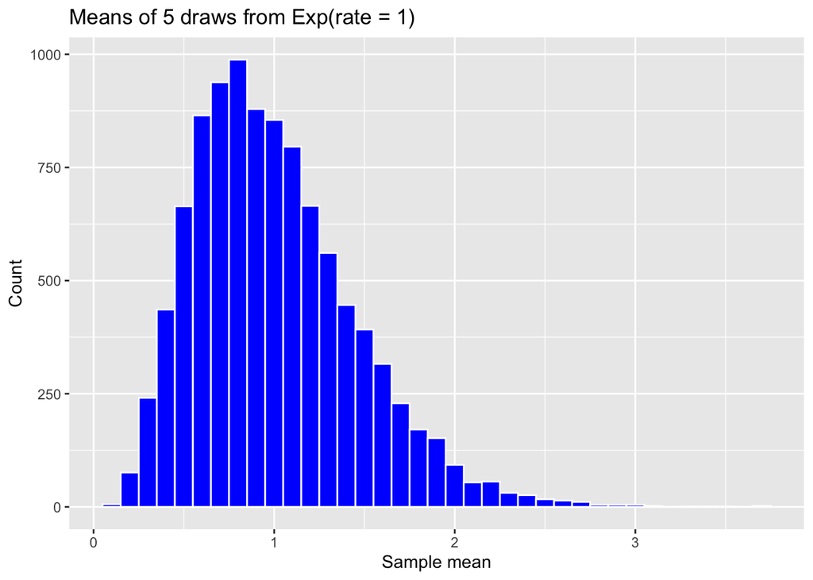

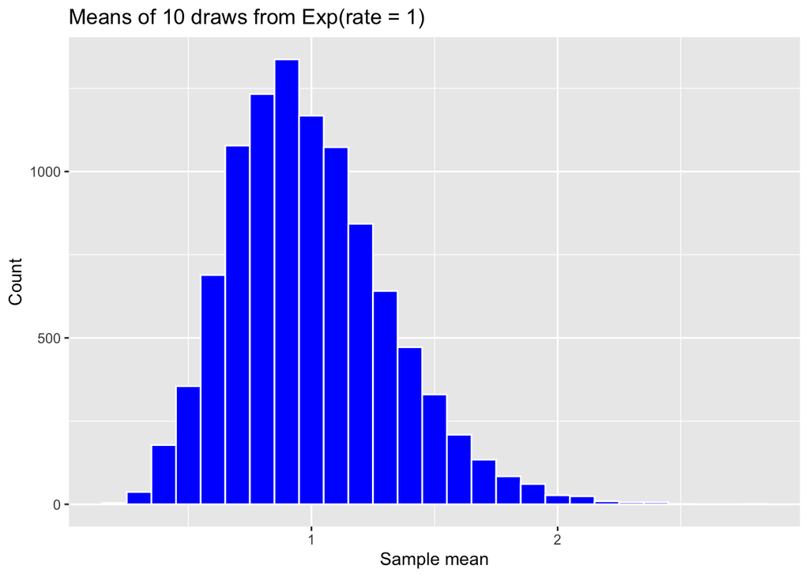

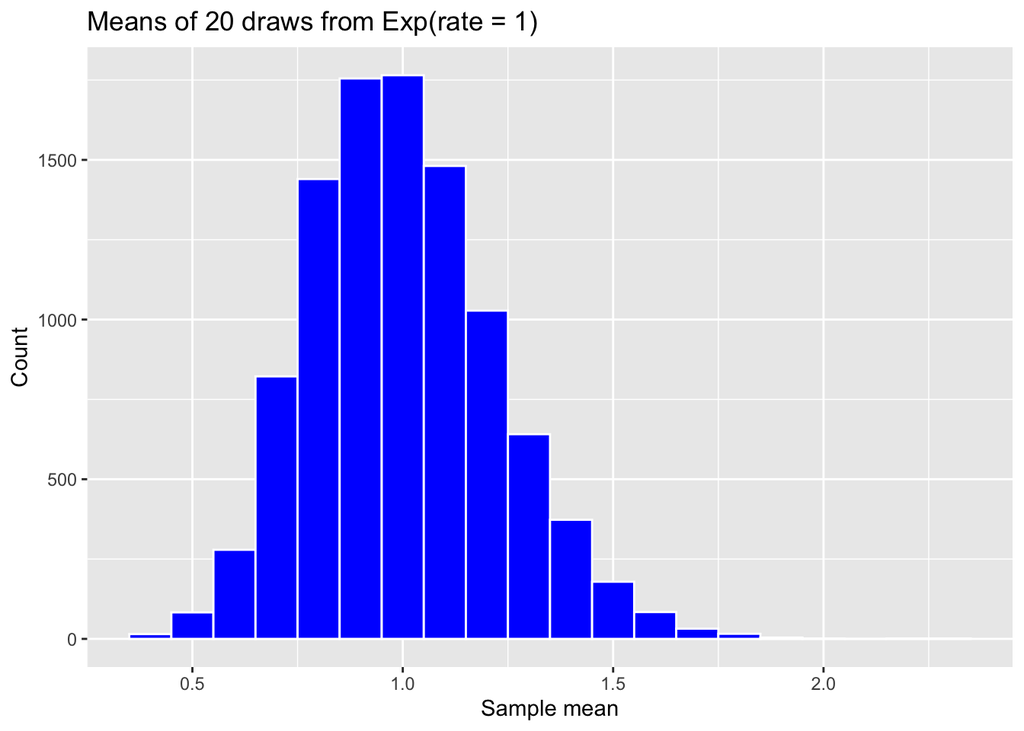

```r
#2c using for loops for samples of 5, 10, 20

#create a loop that runs the function from 2a (with the map function) with
#the requested number of reps

for (n in c(5, 10, 20)) {
  print(exp_means_loop_2a(n)) #this is the function from 2a
}
```

## Problem 3

In this problem, we were taught the “Special For Loop Method.” I used the template to create the code that replaces `df` with the `mtcars` dataframe and the `mean()` function with `sd()` as the problem requires.

```r
q3_output <- vector("double", ncol(mtcars)) #creates the vector with same # of columns
for (i in seq_along(mtcars)) {      #moves the function through each column
  q3_output[[i]] <- sd(mtcars[[i]]) #stores the calculated sd in the vector
}
names(q3_output) <- names(mtcars) #labels the columns with the original column names
q3_output
```

```
        mpg         cyl        disp          hp        drat          wt
  6.0269481   1.7859216 123.9386938  68.5628685   0.5346787   0.9784574
       qsec          vs          am        gear        carb
  1.7869432   0.5040161   0.4989909   0.7378041   1.6152000
```

## Problem 4

In this problem, we were asked to *“Generate a sequence of dates from January 1, 2015 to December 31, 2025, spaced by every two months. Extract the year, quarter, and ISO week number for each date.”*

```r
#Question 4

start_date <- mdy("01-01-2015") #create the start date
end_date <- mdy("12-31-2025") #create the end date

dates <- seq(start_date, end_date, by = "2 months") #creates the sequence

#create a df that will extract the required information for each date
date_table <- data.frame(
  date = dates,
  year = year(dates),
  quarter = quarter(dates),
  ISO_week = isoweek(dates)
)

head(date_table) #prints the first few rows of the resulting table to confirm
```

```
        date year quarter ISO_week
1 2015-01-01 2015       1        1
2 2015-03-01 2015       1        9
3 2015-05-01 2015       2       18
4 2015-07-01 2015       3       27
5 2015-09-01 2015       3       36
6 2015-11-01 2015       4       44
```

## Problem 5

For this problem, we were given a list of sample date and asked to compute the difference in month and weeks between consecutive pairs.

This was a very challenging problem for me. We didn’t learn much about lubridate in Data 612. I had to search extensively in the class notes, and then seek help online for some of the commands (full disclosure). I have a better understanding of lubridate by completing this problem, but I am also not sure if there is a better way to present the final answer other than in decimals. I tried to use `as.period` for the final table, but this did not seem to work.

```r
#Question 5

sample_dates <- c("2018-03-15", "2020-07-20", "2023-01-10", "2025-09-05")

new_dates <- ymd(sample_dates) #convert to dates

class(new_dates) #confirm the class is "date"
```

```
[1] "Date"
```

```r
start_dates <- new_dates[-4] #make a vector of the start dates
end_dates <- new_dates[-1] #made a vector of the end dates

time_spans <- interval(start_dates, end_dates) #use the interval function to calculate
time_spans #confirm it works
```

```
[1] 2018-03-15 UTC--2020-07-20 UTC 2020-07-20 UTC--2023-01-10 UTC
[3] 2023-01-10 UTC--2025-09-05 UTC
```

```r
month_difference <- time_length(time_spans, "month") #convert time_spans to months
weeks_between <- time_length(time_spans, "week") #convert time_spans to weeks

#create a df to store all the values
date_differences <- data.frame(
  starting_date = start_dates,
  ending_date = end_dates,
  months_between = round(month_difference, 1), #rounding to 1 decimal place
  weeks_between = round(weeks_between, 1)
)

date_differences #printing the df
```

```
  starting_date ending_date months_between weeks_between
1    2018-03-15  2020-07-20           28.2         122.6
2    2020-07-20  2023-01-10           29.7         129.1
3    2023-01-10  2025-09-05           31.8         138.4
```

## Problem 6

In this problem, we were given a list of mixed date formats and asked to use `map()` and `possibly()` from the `purrr` package to convert them to date format and extract the month name.

Another fairly challenging problem for me. `Possibly()` is a new function for me, and useful once I figured out how to use it.

```r
#Question 6

date_strings <- list("2023-06-10", "2022/12/25", "15-Aug-2021", "InvalidDate")

safe_dates <- possibly(parse_date_time, otherwise = NA) #use possibly to replace error with NA

#get the fixed dates using map and the new "safe" function
converted_dates <- map(date_strings,safe_dates, orders = c("ymd", "dmy"))
converted_dates #confirm the results
```

```
[[1]]
[1] "2023-06-10 UTC"

[[2]]
[1] "2022-12-25 UTC"

[[3]]
[1] "2021-08-15 UTC"

[[4]]
[1] NA
```

```r
date_vector <- as_date(list_c(converted_dates)) #convert the list into a date vector

class(date_vector) #confirm that it's now a date vector
```

```
[1] "Date"
```

```r
#compile the results in a df
final_table <- data.frame(
  date = date_vector,
  month_name = month(date_vector, label = TRUE, abbr = FALSE) #pulls out the month
)

final_table #print the table
```

```
        date month_name
1 2023-06-10       June
2 2022-12-25   December
3 2021-08-15     August
4       <NA>       <NA>
```